# SI_02_GRANT_US_ORG_ADDR_L1

Grantee street address line 1 · Text report

## Overview

**Description**

Address Foreign - AddressLine1

**Table**

`SI-P02-T01-GRANTS-US-ORGS-GOVTS` (many)

**Location code**

`SCHED-I-PART-02-LINE-01-COL-A`

**Family**

`SCHED-I-PART-02-LINE-01-COL-A` · siblings: SI_02_GRANT_US_ORG_ADDR_CITY, SI_02_GRANT_US_ORG_ADDR_CNTR, SI_02_GRANT_US_ORG_ADDR_L2, SI_02_GRANT_US_ORG_ADDR_STATE, SI_02_GRANT_US_ORG_ADDR_ZIP, SI_02_GRANT_US_ORG_NAME_L1

**Data type**

text (xsd: , StreetAddressType)

**Scope**

PC

**Status**

unreviewed

8

xpaths mapped (6 observed)

532,025

filings with a value

2009–2024

tax years observed

3

open flags (1 errors)

## Flags

| Severity | Flag | Xpath | Detail |
| --- | --- | --- | --- |
| ⚠ error | `COLLISION` | IRS990ScheduleI/RecipientTable/ForeignAddress/AddressLine1Txt | 1885 filings contain 2+ of its xpaths; most common set: /Return/ReturnData/IRS990ScheduleI/RecipientTable/ForeignAddress/AddressLine1Txt ; /Return/ReturnData/IRS990ScheduleI/RecipientTable/USAddress/A… |
| ⓘ info | `UNOBSERVED` | IRS990ScheduleI/Form990ScheduleIPartII/RecipientTable/AddressForeign/AddressLine1 | never observed in TY2009-2024 filings |
| ⓘ info | `UNOBSERVED` | IRS990ScheduleI/Form990ScheduleIPartII/RecipientTable/AddressUS/AddressLine1 | never observed in TY2009-2024 filings |

## Xpaths

All mapped xpaths (under /Return/ReturnData or /Return/ReturnHeader), oldest first. Charts label each series by its xpath.

| Xpath | Form | Chart label | First year | Last year | Versions | Filings | Repeats in |
| --- | --- | --- | --- | --- | --- | --- | --- |
| IRS990ScheduleI/RecipientTable/AddressUS/AddressLine1 | Sched I | same | 2009 | 2012 | 18 | 68,775 | 51.5% |
| IRS990ScheduleI/RecipientTable/AddressForeign/AddressLine1 | Sched I | same | 2009 | 2012 | 13 | 228 | 21.5% |
| IRS990ScheduleI/RecipientTable/USAddress/AddressLine1 | Sched I | same | 2013 | 2013 | 3 | 27,474 | 50.2% |
| IRS990ScheduleI/RecipientTable/ForeignAddress/AddressLine1 | Sched I | same | 2013 | 2013 | 3 | 110 | 18.2% |
| IRS990ScheduleI/RecipientTable/USAddress/AddressLine1Txt | Sched I | same | 2014 | 2024 | 34 | 433,436 | 50.9% |
| IRS990ScheduleI/RecipientTable/ForeignAddress/AddressLine1Txt | Sched I | …90ScheduleI/RecipientTable/ForeignAddress/AddressLine1Txt | 2014 | 2024 | 33 | 2,002 | 24.3% |
| IRS990ScheduleI/Form990ScheduleIPartII/RecipientTable/AddressForeign/AddressLine1 | Sched I | …cheduleIPartII/RecipientTable/AddressForeign/AddressLine1 |  |  |  | 0 |  |
| IRS990ScheduleI/Form990ScheduleIPartII/RecipientTable/AddressUS/AddressLine1 | Sched I | …m990ScheduleIPartII/RecipientTable/AddressUS/AddressLine1 |  |  |  | 0 |  |

## Coverage

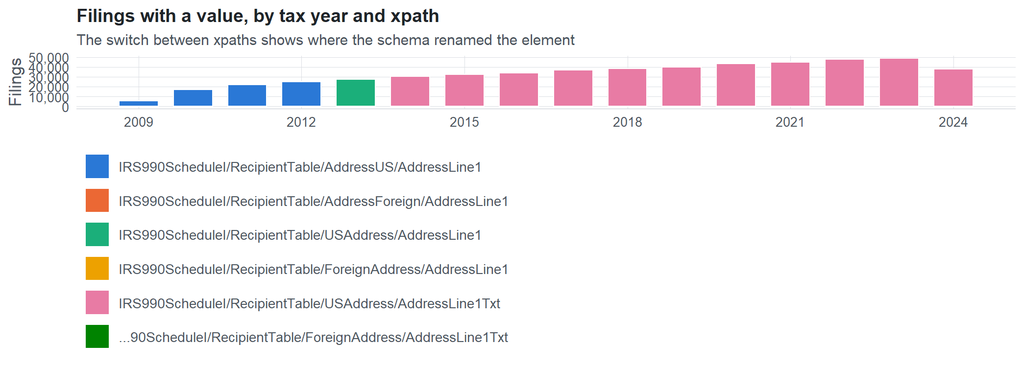

**Table view**

Table view: filings by tax year and series

| Tax year | IRS990ScheduleI/RecipientTable/AddressUS/AddressLine1 | IRS990ScheduleI/RecipientTable/AddressForeign/AddressLine1 | IRS990ScheduleI/RecipientTable/USAddress/AddressLine1 | IRS990ScheduleI/RecipientTable/ForeignAddress/AddressLine1 | IRS990ScheduleI/RecipientTable/USAddress/AddressLine1Txt | …90ScheduleI/RecipientTable/ForeignAddress/AddressLine1Txt |
| --- | --- | --- | --- | --- | --- | --- |
| 2009 | 5,375 | 17 | 0 | 0 | 0 | 0 |
| 2010 | 16,862 | 62 | 0 | 0 | 0 | 0 |
| 2011 | 21,884 | 72 | 0 | 0 | 0 | 0 |
| 2012 | 24,654 | 77 | 0 | 0 | 0 | 0 |
| 2013 | 0 | 0 | 27,474 | 110 | 0 | 0 |
| 2014 | 0 | 0 | 0 | 0 | 30,396 | 122 |
| 2015 | 0 | 0 | 0 | 0 | 32,477 | 122 |
| 2016 | 0 | 0 | 0 | 0 | 33,945 | 148 |
| 2017 | 0 | 0 | 0 | 0 | 36,928 | 184 |
| 2018 | 0 | 0 | 0 | 0 | 38,292 | 182 |
| 2019 | 0 | 0 | 0 | 0 | 39,702 | 166 |
| 2020 | 0 | 0 | 0 | 0 | 43,091 | 182 |
| 2021 | 0 | 0 | 0 | 0 | 44,833 | 228 |
| 2022 | 0 | 0 | 0 | 0 | 47,425 | 243 |
| 2023 | 0 | 0 | 0 | 0 | 48,715 | 240 |
| 2024 | 0 | 0 | 0 | 0 | 37,632 | 185 |

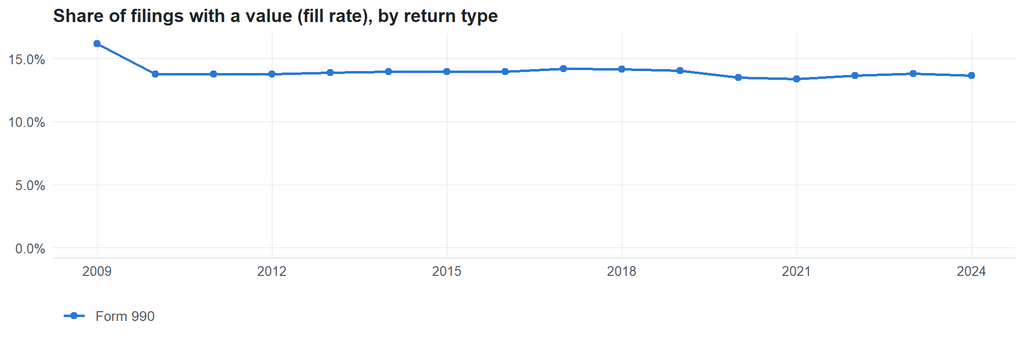

**Table view**

Table view: fill rate

| Tax year | Return type | Filings | All filings | Fill rate |
| --- | --- | --- | --- | --- |
| 2009 | Form 990 | 5,392 | 33,311 | 16.19% |
| 2010 | Form 990 | 16,924 | 123,025 | 13.76% |
| 2011 | Form 990 | 21,956 | 159,504 | 13.77% |
| 2012 | Form 990 | 24,731 | 179,688 | 13.76% |
| 2013 | Form 990 | 27,584 | 198,855 | 13.87% |
| 2014 | Form 990 | 30,518 | 218,619 | 13.96% |
| 2015 | Form 990 | 32,599 | 233,519 | 13.96% |
| 2016 | Form 990 | 34,093 | 243,903 | 13.98% |
| 2017 | Form 990 | 37,112 | 261,612 | 14.19% |
| 2018 | Form 990 | 38,474 | 271,442 | 14.17% |
| 2019 | Form 990 | 39,868 | 283,694 | 14.05% |
| 2020 | Form 990 | 43,273 | 320,342 | 13.51% |
| 2021 | Form 990 | 45,061 | 336,480 | 13.39% |
| 2022 | Form 990 | 47,668 | 349,055 | 13.66% |
| 2023 | Form 990 | 48,955 | 354,768 | 13.80% |
| 2024 | Form 990 | 37,817 | 277,298 | 13.64% |

## Repeating groups

Table cardinality in the concordance: **many**. 6 of 6 observed xpaths repeat within a filing.

Repeating element each xpath was observed in (from the raw indexed xpath)

| Xpath | Repeating element | Filings (summed over years) |
| --- | --- | --- |
| IRS990ScheduleI/RecipientTable/AddressForeign/AddressLine1 | (none) | 26 |
| IRS990ScheduleI/RecipientTable/AddressForeign/AddressLine1 | IRS990ScheduleI/RecipientTable | 202 |
| IRS990ScheduleI/RecipientTable/AddressUS/AddressLine1 | (none) | 32903 |
| IRS990ScheduleI/RecipientTable/AddressUS/AddressLine1 | IRS990ScheduleI/RecipientTable | 35872 |
| IRS990ScheduleI/RecipientTable/ForeignAddress/AddressLine1 | (none) | 17 |
| IRS990ScheduleI/RecipientTable/ForeignAddress/AddressLine1 | IRS990ScheduleI/RecipientTable | 93 |
| IRS990ScheduleI/RecipientTable/USAddress/AddressLine1 | (none) | 13507 |
| IRS990ScheduleI/RecipientTable/USAddress/AddressLine1 | IRS990ScheduleI/RecipientTable | 13967 |
| IRS990ScheduleI/RecipientTable/ForeignAddress/AddressLine1Txt | (none) | 321 |
| IRS990ScheduleI/RecipientTable/ForeignAddress/AddressLine1Txt | IRS990ScheduleI/RecipientTable | 1681 |
| IRS990ScheduleI/RecipientTable/USAddress/AddressLine1Txt | (none) | 210459 |
| IRS990ScheduleI/RecipientTable/USAddress/AddressLine1Txt | IRS990ScheduleI/RecipientTable | 222977 |

## Values

| Result | Check | Detail |
| --- | --- | --- |
| ✓ pass | Values are text, not numbers | 0% of values are numeric |
| ⓘ info | No sign of truncation | IRS990ScheduleI/RecipientTable/AddressForeign/AddressLine1: longest value is exactly 35 characters; IRS990ScheduleI/RecipientTable/ForeignAddress/AddressLine1: longest value is exactly 35 characters; … |
| ✓ pass | No dominant boilerplate value | most common value covers 2% of filings: “601 West Broadway 200” |

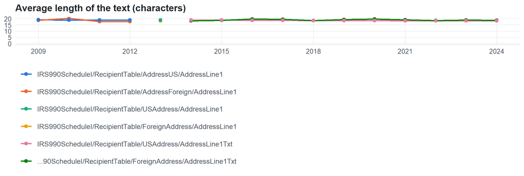

**Table view**

Table view: length and variety by tax year

| Series | Tax year | Filings | Avg length | Max length | Distinct values (approx.) |
| --- | --- | --- | --- | --- | --- |
| IRS990ScheduleI/RecipientTable/AddressUS/AddressLine1 | 2009 | 5,375 | 19 | 35 | 61,108 |
| IRS990ScheduleI/RecipientTable/AddressUS/AddressLine1 | 2010 | 16,862 | 19 | 35 | 128,810 |
| IRS990ScheduleI/RecipientTable/AddressUS/AddressLine1 | 2011 | 21,884 | 19 | 37 | 97,284 |
| IRS990ScheduleI/RecipientTable/AddressUS/AddressLine1 | 2012 | 24,654 | 19 | 35 | 113,761 |
| IRS990ScheduleI/RecipientTable/AddressForeign/AddressLine1 | 2009 | 17 | 19 | 34 | 14 |
| IRS990ScheduleI/RecipientTable/AddressForeign/AddressLine1 | 2010 | 62 | 20 | 35 | 62 |
| IRS990ScheduleI/RecipientTable/AddressForeign/AddressLine1 | 2011 | 72 | 18 | 33 | 101 |
| IRS990ScheduleI/RecipientTable/AddressForeign/AddressLine1 | 2012 | 77 | 18 | 35 | 58 |
| IRS990ScheduleI/RecipientTable/USAddress/AddressLine1 | 2013 | 27,474 | 19 | 35 | 85,012 |
| IRS990ScheduleI/RecipientTable/ForeignAddress/AddressLine1 | 2013 | 110 | 18 | 35 | 57 |
| IRS990ScheduleI/RecipientTable/USAddress/AddressLine1Txt | 2014 | 30,396 | 19 | 37 | 150,630 |
| IRS990ScheduleI/RecipientTable/USAddress/AddressLine1Txt | 2015 | 32,477 | 19 | 35 | 192,912 |
| IRS990ScheduleI/RecipientTable/USAddress/AddressLine1Txt | 2016 | 33,945 | 19 | 35 | 304,877 |
| IRS990ScheduleI/RecipientTable/USAddress/AddressLine1Txt | 2017 | 36,928 | 19 | 35 | 352,304 |
| IRS990ScheduleI/RecipientTable/USAddress/AddressLine1Txt | 2018 | 38,292 | 18 | 35 | 271,769 |
| IRS990ScheduleI/RecipientTable/USAddress/AddressLine1Txt | 2019 | 39,702 | 19 | 35 | 241,817 |
| IRS990ScheduleI/RecipientTable/USAddress/AddressLine1Txt | 2020 | 43,091 | 18 | 36 | 357,838 |
| IRS990ScheduleI/RecipientTable/USAddress/AddressLine1Txt | 2021 | 44,833 | 18 | 37 | 486,980 |
| IRS990ScheduleI/RecipientTable/USAddress/AddressLine1Txt | 2022 | 47,425 | 18 | 37 | 626,651 |
| IRS990ScheduleI/RecipientTable/USAddress/AddressLine1Txt | 2023 | 48,715 | 18 | 37 | 337,050 |
| IRS990ScheduleI/RecipientTable/USAddress/AddressLine1Txt | 2024 | 37,632 | 18 | 35 | 353,752 |
| …90ScheduleI/RecipientTable/ForeignAddress/AddressLine1Txt | 2014 | 122 | 18 | 35 | 106 |
| …90ScheduleI/RecipientTable/ForeignAddress/AddressLine1Txt | 2015 | 122 | 19 | 35 | 62 |
| …90ScheduleI/RecipientTable/ForeignAddress/AddressLine1Txt | 2016 | 148 | 20 | 35 | 176 |
| …90ScheduleI/RecipientTable/ForeignAddress/AddressLine1Txt | 2017 | 184 | 20 | 35 | 148 |
| …90ScheduleI/RecipientTable/ForeignAddress/AddressLine1Txt | 2018 | 182 | 19 | 35 | 210 |
| …90ScheduleI/RecipientTable/ForeignAddress/AddressLine1Txt | 2019 | 166 | 19 | 35 | 135 |
| …90ScheduleI/RecipientTable/ForeignAddress/AddressLine1Txt | 2020 | 182 | 20 | 35 | 185 |
| …90ScheduleI/RecipientTable/ForeignAddress/AddressLine1Txt | 2021 | 228 | 19 | 35 | 233 |
| …90ScheduleI/RecipientTable/ForeignAddress/AddressLine1Txt | 2022 | 243 | 19 | 35 | 578 |
| …90ScheduleI/RecipientTable/ForeignAddress/AddressLine1Txt | 2023 | 240 | 19 | 35 | 209 |
| …90ScheduleI/RecipientTable/ForeignAddress/AddressLine1Txt | 2024 | 185 | 19 | 35 | 198 |

Most common values by xpath (all years; long values truncated)

| Series | Value | Filings | Share |
| --- | --- | --- | --- |
| IRS990ScheduleI/RecipientTable/AddressUS/AddressLine1 | VARIOUS | 230 | 0.3% |
| IRS990ScheduleI/RecipientTable/AddressUS/AddressLine1 | PO BOX 9 | 169 | 0.2% |
| IRS990ScheduleI/RecipientTable/AddressUS/AddressLine1 | 501 ST JUDE PLACE | 135 | 0.2% |
| IRS990ScheduleI/RecipientTable/AddressUS/AddressLine1 | 121 HABITAT STREET | 122 | 0.2% |
| IRS990ScheduleI/RecipientTable/AddressUS/AddressLine1 | PO BOX 100 | 112 | 0.2% |
| IRS990ScheduleI/RecipientTable/AddressUS/AddressLine1 | PO BOX 500 | 77 | 0.1% |
| IRS990ScheduleI/RecipientTable/AddressUS/AddressLine1 | 262 DANNY THOMAS PLACE | 75 | 0.1% |
| IRS990ScheduleI/RecipientTable/AddressUS/AddressLine1 | 1275 YORK AVENUE | 71 | 0.1% |
| IRS990ScheduleI/RecipientTable/AddressUS/AddressLine1 | PO BOX 3000 | 43 | 0.1% |
| IRS990ScheduleI/RecipientTable/AddressUS/AddressLine1 | 1154 TOWN COUNTRY COMMONS DRIVE | 41 | 0.1% |
| IRS990ScheduleI/RecipientTable/AddressUS/AddressLine1 | PO BOX 309 | 39 | 0.1% |
| IRS990ScheduleI/RecipientTable/AddressUS/AddressLine1 | PO BOX 217 | 33 | 0.0% |
| IRS990ScheduleI/RecipientTable/AddressUS/AddressLine1 | 345 SPEAR STREET SUITE 700 | 32 | 0.0% |
| IRS990ScheduleI/RecipientTable/AddressUS/AddressLine1 | 125 MAIDEN LANE | 28 | 0.0% |
| IRS990ScheduleI/RecipientTable/AddressUS/AddressLine1 | 2025 E STREET NW | 28 | 0.0% |
| IRS990ScheduleI/RecipientTable/AddressUS/AddressLine1 | 3451 WALNUT STREET | 28 | 0.0% |
| IRS990ScheduleI/RecipientTable/AddressUS/AddressLine1 | 700 CHILDRENS DRIVE | 28 | 0.0% |
| IRS990ScheduleI/RecipientTable/AddressUS/AddressLine1 | 121 Habitat Street | 20 | 0.0% |
| IRS990ScheduleI/RecipientTable/AddressUS/AddressLine1 | PO Box 9 | 15 | 0.0% |
| IRS990ScheduleI/RecipientTable/AddressUS/AddressLine1 | 121 Steuart Street | 14 | 0.0% |
| IRS990ScheduleI/RecipientTable/AddressUS/AddressLine1 | 25 Broadway Suite 1700 | 13 | 0.0% |
| IRS990ScheduleI/RecipientTable/AddressUS/AddressLine1 | 3451 Walnut Street | 12 | 0.0% |
| IRS990ScheduleI/RecipientTable/AddressUS/AddressLine1 | 4601 Community Drive | 11 | 0.0% |
| IRS990ScheduleI/RecipientTable/AddressUS/AddressLine1 | 1275 York Avenue | 10 | 0.0% |
| IRS990ScheduleI/RecipientTable/AddressUS/AddressLine1 | 200 First Street SW | 10 | 0.0% |
| IRS990ScheduleI/RecipientTable/AddressForeign/AddressLine1 | HC06 Box 10240 | 2 | 0.9% |
| IRS990ScheduleI/RecipientTable/AddressForeign/AddressLine1 | PO BOX 2989 | 2 | 0.9% |
| IRS990ScheduleI/RecipientTable/AddressForeign/AddressLine1 | 212 HENRY STREET | 2 | 0.9% |
| IRS990ScheduleI/RecipientTable/AddressForeign/AddressLine1 | PO BOX 22945 GMF | 2 | 0.9% |
| IRS990ScheduleI/RecipientTable/AddressForeign/AddressLine1 | 1 CONWAY STREET FITZROY SQUARE | 2 | 0.9% |

First rows shown.

## Examples

| Tax year | Return | Xpath | Organization | Value | Source |
| --- | --- | --- | --- | --- | --- |
| 2024 | 990 | IRS990ScheduleI/RecipientTable/ForeignAddress/AddressLine1Txt | ENGINEER FAMILY FOUNDATION | KK Navsari Chambers FL 39 B | [XML](https://gt990datalake-rawdata.s3.amazonaws.com/EfileData/XmlFiles/202533199349303258_public.xml) |
| 2024 | 990 | IRS990ScheduleI/RecipientTable/USAddress/AddressLine1Txt | THE CLEVELAND CLINIC FOUNDATION | 2717 W CYPRESS CREEK ROAD | [XML](https://gt990datalake-rawdata.s3.amazonaws.com/EfileData/XmlFiles/202513189349302136_public.xml) |
| 2023 | 990 | IRS990ScheduleI/RecipientTable/ForeignAddress/AddressLine1Txt | COANIQUEM BURN CENTER AID | 8586 PUDAHUEL | [XML](https://gt990datalake-rawdata.s3.amazonaws.com/EfileData/XmlFiles/202441239349302764_public.xml) |
| 2023 | 990 | IRS990ScheduleI/RecipientTable/USAddress/AddressLine1Txt | ZEPF CENTER | 6605 W CENTRAL AVENUE | [XML](https://gt990datalake-rawdata.s3.amazonaws.com/EfileData/XmlFiles/202423399349300887_public.xml) |
| 2022 | 990 | IRS990ScheduleI/RecipientTable/ForeignAddress/AddressLine1Txt | IHC HEALTH SERVICES INC | 7 HRUSHEVSKY STREET | [XML](https://gt990datalake-rawdata.s3.amazonaws.com/EfileData/XmlFiles/202313159349300546_public.xml) |
| 2022 | 990 | IRS990ScheduleI/RecipientTable/USAddress/AddressLine1Txt | International Brotherhood of 896 TCWH | 25 Louisiana Ave NW | [XML](https://gt990datalake-rawdata.s3.amazonaws.com/EfileData/XmlFiles/202303139349304500_public.xml) |
| 2021 | 990 | IRS990ScheduleI/RecipientTable/ForeignAddress/AddressLine1Txt | THE VERMONT COMMUNITY FOUNDATION | 11 INNOVATION BLVD | [XML](https://gt990datalake-rawdata.s3.amazonaws.com/EfileData/XmlFiles/202213199349316836_public.xml) |
| 2021 | 990 | IRS990ScheduleI/RecipientTable/USAddress/AddressLine1Txt | CAMP JOHN MARC FOUNDATION INC | 4925 GREENVILLE AVENUE SUITE 400 | [XML](https://gt990datalake-rawdata.s3.amazonaws.com/EfileData/XmlFiles/202241039349300339_public.xml) |
| 2020 | 990 | IRS990ScheduleI/RecipientTable/ForeignAddress/AddressLine1Txt | IMMANUEL AGAPE MINISTRIES | 12 Avenida 1-60 Residencial | [XML](https://gt990datalake-rawdata.s3.amazonaws.com/EfileData/XmlFiles/202143199349326849_public.xml) |
| 2020 | 990 | IRS990ScheduleI/RecipientTable/USAddress/AddressLine1Txt | GREATER FARGO MOORHEAD ECONOMIC | 4351 23RD AVENUE SOUTH | [XML](https://gt990datalake-rawdata.s3.amazonaws.com/EfileData/XmlFiles/202102679349301200_public.xml) |
| 2019 | 990 | IRS990ScheduleI/RecipientTable/ForeignAddress/AddressLine1Txt | SOCIETY OF URODYNAMICS & FEMALE | 2500 University Drive NW | [XML](https://gt990datalake-rawdata.s3.amazonaws.com/EfileData/XmlFiles/202041709349300204_public.xml) |
| 2019 | 990 | IRS990ScheduleI/RecipientTable/USAddress/AddressLine1Txt | The Textile Museum | 1918 F STREET NW | [XML](https://gt990datalake-rawdata.s3.amazonaws.com/EfileData/XmlFiles/202012819349301126_public.xml) |

## Reviewer checklist

- The definition matches the form line and instructions for every xpath’s schema years.
- Every xpath pooled here measures the same thing on the 990 and 990-EZ (close enough for analysis).
- The coverage chart has no unexplained gaps or jumps between tax years.
- Each open flag is fixed, or accepted with a note in validation_log.csv.
- Values answer the question on the form line (not another line’s explanation).
- Boilerplate such as ‘See Schedule O’ or ‘N/A’ is expected here, or should be treated as missing.
- Text that is really a number or a code is flagged for a different data type.

Record the review as a row in `inst/extdata/src/validation_log.csv` (variable_name, reviewer, date, status, note). Evidence built 2026-09-23 17:09:04 MST from the ef2 DuckDB builds (tax years 2009–2024).